# Regressie O & S: Bijeenkomst 1

Elmar Jansen

14 mei 2024

# Data laden

Eerst moeten we de data inladen. Kies hieronder de software waarin je werkt voor instructies.

## R

1. Om de data in te laden hebben we het pakket `haven` nodig. Dit pakket kan SPSS-bestanden inlezen. Als je dat nog niet hebt geïnstalleerd, doe dat dan eerst met `install.packages('haven')`.
2. Vervolgens laden we de data in met de volgende code:

```r
library(haven)
buurten <- read_sav("https://elmarjansen.nl/data/cbs_buurten_amsterdam.sav")
```

## SPSS

Instructies voor SPSS:

1. Download het bestand [hier](https://elmarjansen.nl/data/cbs_buurten_amsterdam.sav).
2. Open het bestand in SPSS.

# Oefening 1: enkelvoudige regressie

We gaan de eerste regressie uitvoeren. We gebruiken een dataset waarin CBS-gegevens over Amsterdamse buurten bijeen zijn gebracht.

We onderzoeken de relatie tussen het effect van de gemiddelde huishoudgrootte in een buurt op het gemiddeld aantal auto’s per huishouden in die buurt.

## Variabelen

### Vraag

Bedenk voordat we verdergaan wat hier de *afhankelijke variabele* is en wat de *onafhankelijke variabele* is.

### Antwoord

- De **afhankelijke variabele** is het gemiddeld aantal auto’s per huishouden in een buurt (`autos_per_hh`).
- De **onafhankelijke variabele** is de gemiddelde huishoudgrootte in een buurt (`hh_grootte`).

## Scatterplot

Om te beginnen maken we een scatterplot van de twee variabelen voor een eerste idee van de samenhang.

Denk er aan dat het gebruikelijk is om de afhankelijke variabele op de y-as te zetten en de onafhankelijke variabele op de x-as.

### Extra hulp

#### Instructies

Als je niet zeker weet hoe je dat moet doen, klik je hier boven op de tab die hoort bij de software waarin je werkt.

#### R

In R gebruik je de `plot` functie om een scatterplot te maken.

```r
plot(buurten$hh_grootte, buurten$autos_per_hh, xlab = "Gem. grootte huishoudens", ylab = "Gem. auto's per huishouden")
```

#### SPSS

In SPSS kun je een scatterplot maken door naar `Graphs` > `Scatter/Dot` te gaan en daar te kiezen voor `Simple`.

Zet vervolgens `autos_per_hh` op de Y-as en `hh_grootte` op de X-as en druk op OK.

## Regressievergelijking

### Vraag

Schrijf nu voor jezelf eerst de regressievergelijking uit. Dit is de vergelijking die we straks gaan invullen.

### Antwoord

De regressievergelijking is:

$${autos\_per\_hh}_i = \beta_0 + \beta_1 \times {hh\_grootte}_i +
\epsilon_i$$

## Regressie uitvoeren

Nu gaan we de regressie uitvoeren.

### Instructies

Voer de regressie uit in R of SPSS. Kies hierboven de software waarin je werkt voor instructies.

### R

In R voer je de regressie uit met de `lm` functie.

Het is handig om het resultaat (het model) alvast op te slaan in een object, bijvoorbeeld `model1`. Op die manier kunnen we het model later verder bestuderen en gebruiken.

```r
model1 <- lm(autos_per_hh ~ hh_grootte, data = buurten)
model1
```

[output not shown]

Je ziet zo als het goed is de schatting voor de constante $\beta_0$ (Intercept) en de helling-coefficient van `hh_grootte` $\beta_1$.

Voor meer informatie over het model (hebben we nu nog niet nodig) kun je de `summary` functie gebruiken:

```r
summary(model1)
```

```
##
## Call:
## lm(formula = autos_per_hh ~ hh_grootte, data = buurten)
##
## Residuals:
##      Min       1Q   Median       3Q      Max
## -0.35595 -0.12057 -0.06430  0.07108  1.81900
##
## Coefficients:
##             Estimate Std. Error t value Pr(>|t|)
## (Intercept) -0.34603    0.05040  -6.866 2.49e-11 ***
## hh_grootte   0.47912    0.02729  17.554  < 2e-16 ***
## ---
## Signif. codes:  0 '***' 0.001 '**' 0.01 '*' 0.05 '.' 0.1 ' ' 1
##
## Residual standard error: 0.2057 on 405 degrees of freedom
##   (72 observations deleted due to missingness)
## Multiple R-squared:  0.4321, Adjusted R-squared:  0.4307
## F-statistic: 308.2 on 1 and 405 DF,  p-value: < 2.2e-16
```

### SPSS

1. Ga naar `Analyze` > `Regression` > `Linear`.
2. Zet `autos_per_hh` als afhankelijke variabele en `hh_grootte` als onafhankelijke variabele.
3. Klik op `Statistics` en zet een vinkje bij `Estimates` en bij `Confidence Intervals`, en druk op Continue.
4. Druk op OK.
5. Kijk naar de laatste tabel in de output. Onder “unstandardized coefficients” zie je de schattingen voor $\beta_0$ (Constant) en $\beta_1$.

## Regressielijn in grafiek

We kunnen nu ook de regressielijn toevoegen aan de scatterplot die we eerder maakten, zodat we ook kunnen zien welke lijn het model heeft geschat.

### Instructies

Kies hierboven de software waarin je werkt voor instructies.

### R

In R kun je de regressielijn toevoegen met de `abline` functie. Je hebt daarvoor het model nodig dat je eerder hebt opgeslagen.

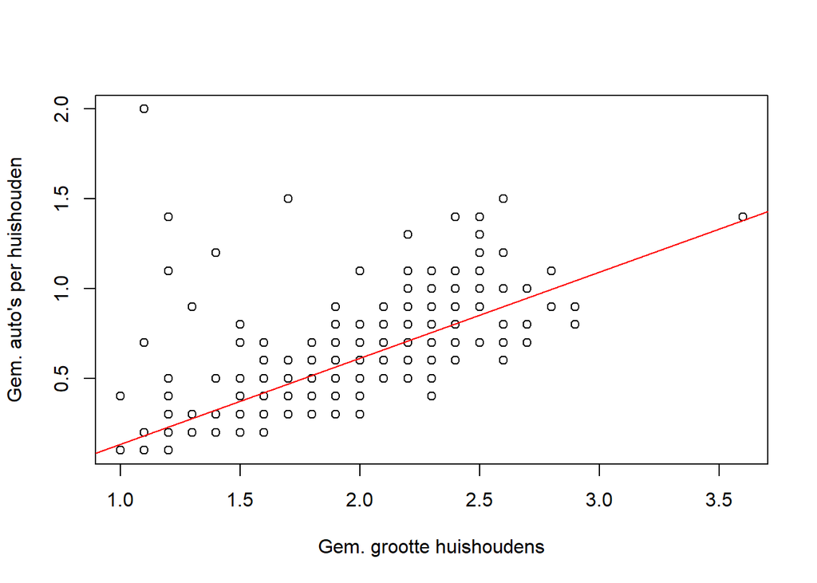

```r
plot(buurten$hh_grootte, buurten$autos_per_hh, xlab = "Gem. grootte huishoudens", ylab = "Gem. auto's per huishouden")
abline(model1, col = "red")
```

### SPSS

1. Dubbelklik op de scatterplot om de *chart editor* te openen.
2. Ga naar `Elements` > `Fit Line at Total`.
3. Kies voor `Linear` en klik Close.

## Regressievergelijking ingevuld

### Vraag

Schrijf nu voor jezelf de regressievergelijking uit, maar dan met de geschatte waarden voor $\beta_0$ en $\beta_1$ ingevuld.

### Antwoord

De geschatte regressievergelijking is:

$$\text{autos_per_hh}_i = -0.35 + 0.48 \times \text{hh_grootte}_i$$

## Interpretatie constante

### Vraag

Bedenk de precieze interpretatie van het getal -0.35 (de constante $\beta_0$).

### Antwoord

De constante $\beta_0$ is -0.35.

Dit betekent dat als de gemiddelde huishoudgrootte in een buurt 0 is (dat kan natuurlijk niet, dus theoretisch), het gemiddeld aantal auto’s per huishouden -0.35 is.

## Interpretatie helling

### Vraag

Bedenk de precieze interpretatie van het getal 0.48 (de helling-coefficient $\beta_1$).

### Antwoord

De helling-coefficient $\beta_1$ is 0.48.

Dit betekent dat als de gemiddelde huishoudgrootte in een buurt met 1 toeneemt, het gemiddeld aantal auto’s per huishouden met 0.48 toeneemt.

# Oefening 2: meervoudige regressie

We voeren nu een meervoudige regressie uit, door één variabele toe te voegen aan het model: het percentage koopwoningen (`woning_koop`).

## Variabelen

### Vraag

Bedenk weer wat hier de *afhankelijke variabele* is en wat de *onafhankelijke variabele* zijn.

### Antwoord

- De **afhankelijke variabele** is het gemiddeld aantal auto’s per huishouden in een buurt (`autos_per_hh`).
- De **onafhankelijke variabele** zijn:
  - de gemiddelde huishoudgrootte in een buurt (`hh_grootte`).
  - het percentage koopwoningen in een buurt (`woning_koop`).

## Regressievergelijking

### Vraag

Schrijf de regressievergelijking uit. Dit is de vergelijking die we straks gaan invullen.

### Antwoord

De regressievergelijking is:

$${autos\_per\_hh}_i = \beta_0 + \beta_1 \times {hh\_grootte}_i + \beta_2
\times {woning\_koop}_i + \epsilon_i$$

## Regressie uitvoeren

Nu gaan we de regressie uitvoeren.

### Instructies

Voer de regressie uit in R of SPSS. Kies hierboven de software waarin je werkt voor instructies.

### R

In R voer je de regressie uit met de `lm` functie.

```r
model2 <- lm(autos_per_hh ~ hh_grootte + woning_koop, data = buurten)
summary(model2)
```

[output not shown]

Je ziet zo als het goed is de schatting voor de constante $\beta_0$ (Intercept) en de helling-coefficienten van `hh_grootte` $\beta_1$ en van `woning_koop` $\beta_2$.

### SPSS

1. Ga naar `Analyze` > `Regression` > `Linear`.
2. Zet `autos_per_hh` als afhankelijke variabele en `hh_grootte` als onafhankelijke variabele (waarschijnlijk staan ze nog ingevuld) en voeg `woning_koop` toe als onafhankelijke variabele.
3. Druk op OK.
4. Kijk naar de laatste tabel in de output. Onder “unstandardized coefficients” zie je de schattingen voor $\beta_0$ (Constant), $\beta_1$ en $\beta_2$..

## Regressievergelijking ingevuld

### Vraag

Schrijf voor jezelf de regressievergelijking uit met de geschatte waarden voor $\beta_0$, $\beta_1$ en $\beta_2$ ingevuld.

### Antwoord

De geschatte regressievergelijking is:

$$\text{autos_per_hh}_i = -0.30 + 0.37 \times \text{hh_grootte}_i + 0.004
\times \text{woning\_koop}_i$$

## Interpretatie $\beta_1$

### Vraag

Bedenk de precieze interpretatie van het getal 0.37 (de helling-coefficient $\beta_1$).

### Antwoord

De helling-coefficient $\beta_1$ is 0.37.

Dit betekent dat als de gemiddelde huishoudgrootte in een buurt met 1 toeneemt terwijl het percentage koopwoningen niet verandert, het gemiddeld aantal auto’s per huishouden met 0.37 toeneemt.

## Interpretatie $\beta_2$

### Vraag

Bedenk de precieze interpretatie van het getal 0.004 (de helling-coefficient $\beta_2$).

### Antwoord

De helling-coefficient $\beta_2$ is 0.004.

Dit betekent dat als het percentage koopwoningen in een buurt met 1 toeneemt terwijl huishoudens even groot blijven, het gemiddeld aantal auto’s per huishouden met 0.004 toeneemt.

## Interpretatie standaardfout van $\beta_1$

### Vraag

Bedenk de precieze interpretatie van het getal 0.028 (de standaardfout van de helling-coefficient $\beta_1$).

### Antwoord

de standaardfout van de helling-coefficient $\beta_1$ is 0.03.

Dit betekent dat de werkelijke waarde van $\beta_1$ gemiddeld 0.03 afwijkt van de geschatte waarde van 0.37 (let op: het kan ook meer zijn, of juist vel minder)

## Interpretatie $R^2$

### Vraag

Geef de interpretatie van het getal 0.62 (de $R^2$).

### Antwoord

Het $R^2$ is 0.62.

Dit betekent dat 62% van de buurtvariatie in het gemiddeld aantal auto’s per huishouden verklaard kan worden door de combinatie gemiddelde huishoudgrootte en het percentage koopwoningen in een buurt.

Bedenk: dat is een veel hoger percentage dan je meestal zult tegenkomen in sociaal wetenschappelijk onderzoek, het is een opvallend sterk verklarend model.

## Interpretatie $F$-test

### Vraag

Geef de interpretatie van de p-waarde die bij de F-test hoort.

### Antwoord

De p-waarde is kleiner dan 0.000001. We kunnen dus concluderen dat het model als geheel significant is (je bent echt een betere voorspeller van autobezit met dit model, dan wanneer je alleen het gemiddelde zou nemen).

## Interpretatie $T$-test

### Vraag

Geef de interpretatie van de p-waarde die bij de T-test van hh_grootte hoort.

### Antwoord

De p-waarde is kleiner dan 0.000001. We kunnen dus concluderen dat de gemiddelde huishoudgrootte in een buurt een significant effect heeft op het gemiddeld aantal auto’s per huishouden in die buurt.

# Slides

[interactive chart not shown]